# Programa de Pós-Graduação em Estatística Aplicada (PPGEAp) - DEMAT/ICE/UFRRJ

Tópicos de Correlação e Regressão

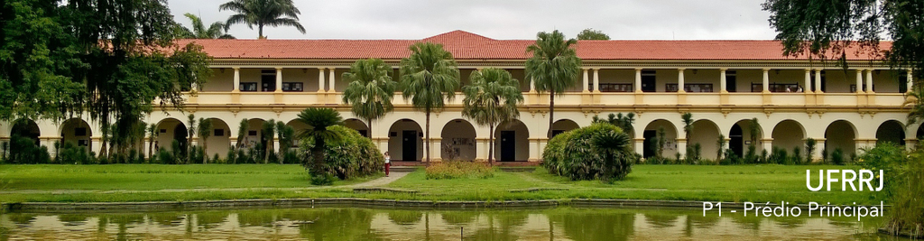

## Professores:

- Adriana Andrade (DEMAT/ICE/UFRRJ) (*andrade.ufrrj@gmail.com*)
- Wagner Tassinari (DEMAT/ICE/UFRRJ) (*tassinari@ufrrj.br*)

## Objetivo da Disciplina

Apresentar uma visão geral dos aspectos da modelagem estatística com ênfase nos Modelos de Regressão Linear, simples e múltipla, além de técnicas de estimação pontual e intervalar, análises da adequação e da qualidade do modelo, seleção de modelos e uso de variáveis dummies.

## Pacote estatístico R

- Neste curso também está previsto a utilização do **pacote estatístico R** utilizando a interface gráfica do **RStudio**. O pacote estatístico R, que pode ser encontrado no site oficial do projeto CRAN ([link](https://cran.r-project.org/)). O pacote estatístico R é uma linguagem de programação estatística e gráfica direcionada para a manipulação, visualização e análise estatística de dados, que atualmente vem sendo considerada uma das melhores ferramentas para essa finalidade. A linguagem ainda possui como diferencial a facilidade no aprendizado, mesmo para aqueles que nunca tiveram contato anterior com programação. O pacote estatístico R é um *software* livre (*free*) e de código aberto (*open source*) para análise de dados.
- Uma das formas de utilizar a linguagem R é através da interface gráfica **RStudio** ([link](https://rstudio.com/products/rstudio/)), que é uma IDE ou ambiente de desenvolvimento integrado, para o pacote R. Com sua utilização gratuita, o RStudio é uma excelente ferramenta para trabalhar com o R. Essa plataforma é extremamente visual quando comparado com ambientes de outras linguagens e também com o console do R, e muito simples de se utilizar.

# Programa da Disciplina

| Tópicos | Conteúdo |
| --- | --- |
| **1** | **Modelo de Regressão Linear Simples (MRLS)** |
| **1.1** | Introdução à Modelagem Estatística |
| **1.2** | Forma do Modelo de MRLS |
| **1.3** | Suposições do MRLS |
| **1.4** | Estimação dos Parâmetros do MRLS |
| **2** | **Modelo de Regressão Linear Simples (MRLS)** |
| **2.1** | Predição no MRLS |
| **2.2** | ANOVA da Regressão |
| **2.3** | Adequação do Ajuste |
| **2.4** | Medidas Corretivas |
| **3.** | **Regressão Linear Múltipla** |
| **3.1** | Introdução a MRLM |
| **3.2** | Pressupostos do MRLM |
| **3.3** | Notação matricial |
| **3.4** | Estimação dos Parâmetros |
| **3.5** | TH’s e IC’s para os MRLM |
| **3.6** | ANOVA para os MRLM |
| **4.** | **Regressão Linear Múltipla** |
| **4.1** | Verificação da Adequação do MRLM |
| **4.2** | Multicolinearidade |
| **4.3** | Métodos de Seleção de Variáveis |
| **4.4** | Métricas para aferir a qualidade do ajuste |
| **4.5** | Variáveis dummy |

# Avaliação da Disciplina

- A avaliação da disciplina será realizada por um seminário dividido entre apresentação e entrega de relatório. A Nota Final será obtida pela média ponderada entre a nota da apresentação(0,4) e a nota do relatório(0,6).

**Obs:** Os seminários deverão ser feitos segundo as seguintes orientações: link

# Bibliografia

- Faraway, J. Practical Regression and Anova using R (PDF, banco de dados e scripts disponível no site [link](https://julianfaraway.github.io/faraway/PRA/pra.pdf))
- Fox, J (2002). An R and S-Plus Companion to Applied Regression. Sage Publications.

# Cronograma

| Data | Aula | Descrição |
| --- | --- | --- |
| 04/11/2022 | 1 | Modelo de Regressão Simples |
| 11/11/2022 | 2 | Modelo de Regressão Simples |
| 18/11/2022 | 3 | Modelo de Regressão Múltipla |
| 19/11/2022 | 4 | Modelo de Regressão Múltipla |
| 25/11/2022 | 5 | Apresentação dos Seminários |

# **Aula 1: Modelo de Regressão Linear Simples**

| Material | Links |
| --- | --- |
| Slides | link |
| Exercício | link |
| Gabarito | link |

# **Aula 2: Modelo de Regressão Linear Simples**

| Material | Links |
| --- | --- |
| Slides | link |
| Exercício | link |
| Gabarito | link |

# **Aula 3: Modelo de Regressão Linear Múltipla**

| Material | Links |
| --- | --- |
| Slides | link |
| Exercício | link |
| Gabarito | link |

# **Aula 4: Modelo de Regressão Linear Múltipla**

| Material | Links |
| --- | --- |
| Slides | link |
| Dados | link |